# Análise da Participação Feminina nos Jogos Olímpicos

Thais Pereira

Setembro de 2021

**1. Introdução**

Esta é uma análise a respeito da participação feminina nos Jogos Olímpicos, produzida a partir da base de dados a respeito dos jogos disponibilizada pelo evento TidyTuesday. O dataset é composto por quinze variáveis a respeito de todos os competidores que participaram de jogos olímpicos entre 1896 e 2016. Nessa tabela podemos observar o quantitativo resumido das informações contidas neste dataset:

| Competidores | Competidores Homens | Competidoras Mulheres | Países dos Competidores | Olimpíadas | Cidades dos Eventos | Esportes |
| --- | --- | --- | --- | --- | --- | --- |
| 135.571 | 101590 | 33981 | 230 | 51 | 42 | 66 |

**2. Comparativo da série histórica 1986-2016**

Originalmente os jogos olímpicos eram realizados na cidade de Olímpia na Grécia, e aconteceram entre o século VIII a.C e V d.C. Os jogos Omlípicos da era moderna foram idealizados pelo Barão Pierre de Coubertin (1863-1937) para acontecerem do mesmo modo que na antiguidade clássica, portanto excluindo as mulheres de participarem das competições. A primeira edição ocorreu oficiamente em 6 de abril de 1896 em Atenas na Grécia. A participação feminina só foi permitida na segunda Olimpíada, que aconteceu em 1900, nos próximos gráficos vamos falar mais detalhadamente dessa participação e seus número. Mas primeiramente, vamos observar a série histórica dos jogos e entender a evolução da participação feminina.

[figure not shown]

[figure not shown]

Aqui podemos observar a quantidade de medalhas de ouro, prata e bronze, conquistadas por mulheres e homens ao longos dos anos nas Olimpíadas. Interessante observar que os pontos da série histórica seguem o mesmo padrão dos gráficos anteriores, ou seja, conforme as mulheres foram ganhando espaço e participando mais dos jogos, a quantidade de medalhadas conquistadas também foi aumentando até alcançar, nas últimas olimpíadas, proporções bem próximas à masculina, e esse fenômeno se repeto para os três tipos existentes de medalhas.

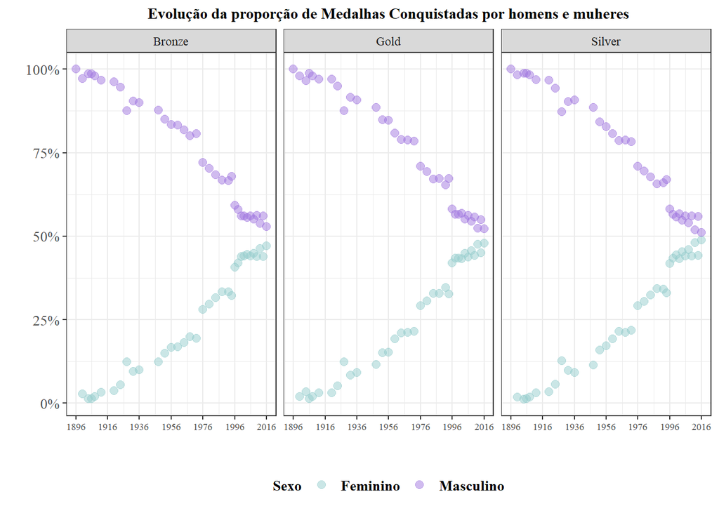

Abaixo temos um gráfico de calor sobre o mapa mundi nos mostrando a quantidade total de mulheres em olímpiadas em todos os países para o qual temos informações no dataset utilizado para essa análise. Estados Unidos e China aprecem como países com grande número de mulheres em Olmpíadas em relação aos outros países.

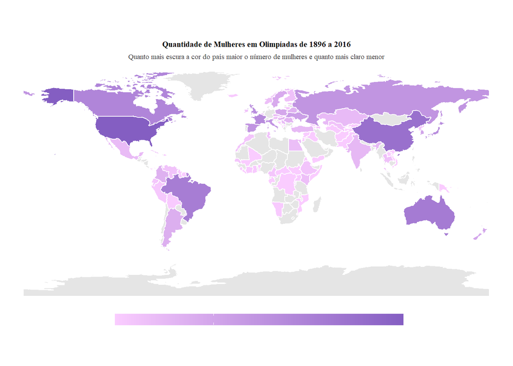

O gráfico abaixo é como se fosse um recorte do gráfico anterior, todavia nele estamos olhando para a proporção de homens e mulheres em olimpíadas (1986 - 2016), apenas nos países da América Latina, para que possamos compará-los entre si. Peru, Brasil e Colômbia são, respectivamente, os países com mais mulheres em olimpíadas, ao passo que Uruguai, Chile e Paraguai são os países com menos mulheres.

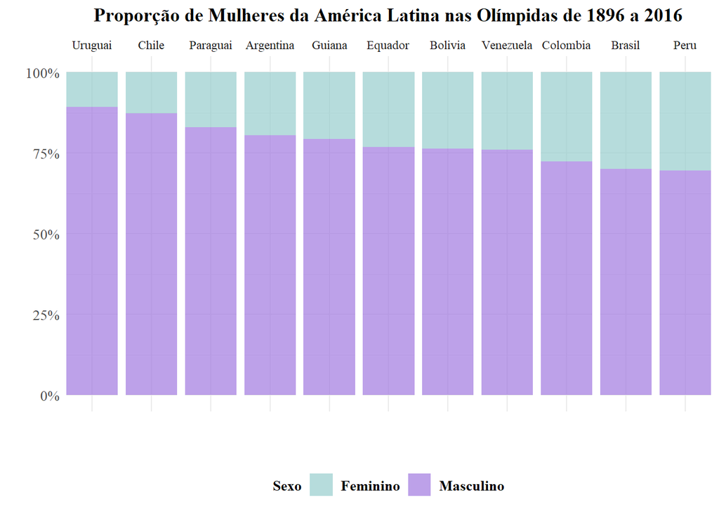

**3. A Olimpíada do ano de 1900**

A Olimpíada de 1900 que aconteceu em Paris na França é um marco histórico para a participação feminina, visto que foi o primeiro evento em que houve mulheres competidoras, no evento anterior, o primeiro da era moderna, as mulheres foram proibidas de participar, pois segundo o idealizador do evento, Pierre de Coubertin (1863-1937), “É indecente ver mulheres torcendo-se no exercício físico do esporte”. O gráfico a seguir nos mostra os países a qual pertenciam as mulheres que participaram da Olimpíada de 1900, assim como todos os outros países que estiveram na competição com equipe majoritariamente masculina.

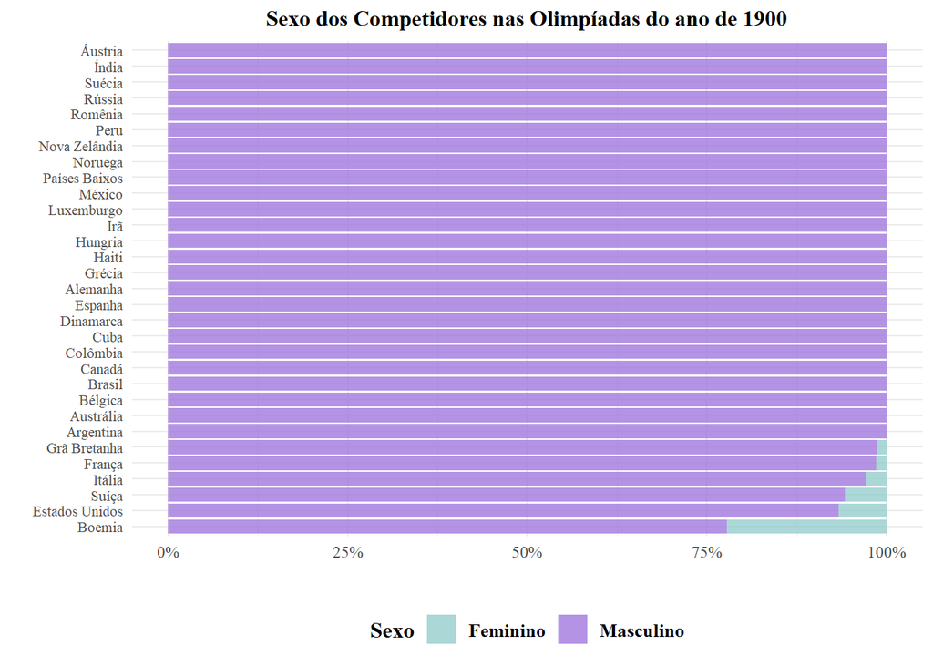

No gráfico a seguir podemos observar quais foram os esportes que as mulheres das Olimpíadas de 1900 concorreram: foram cinco esportes, sendo que a maioria das competidoras disputram medalhas jogando tênis e golf.

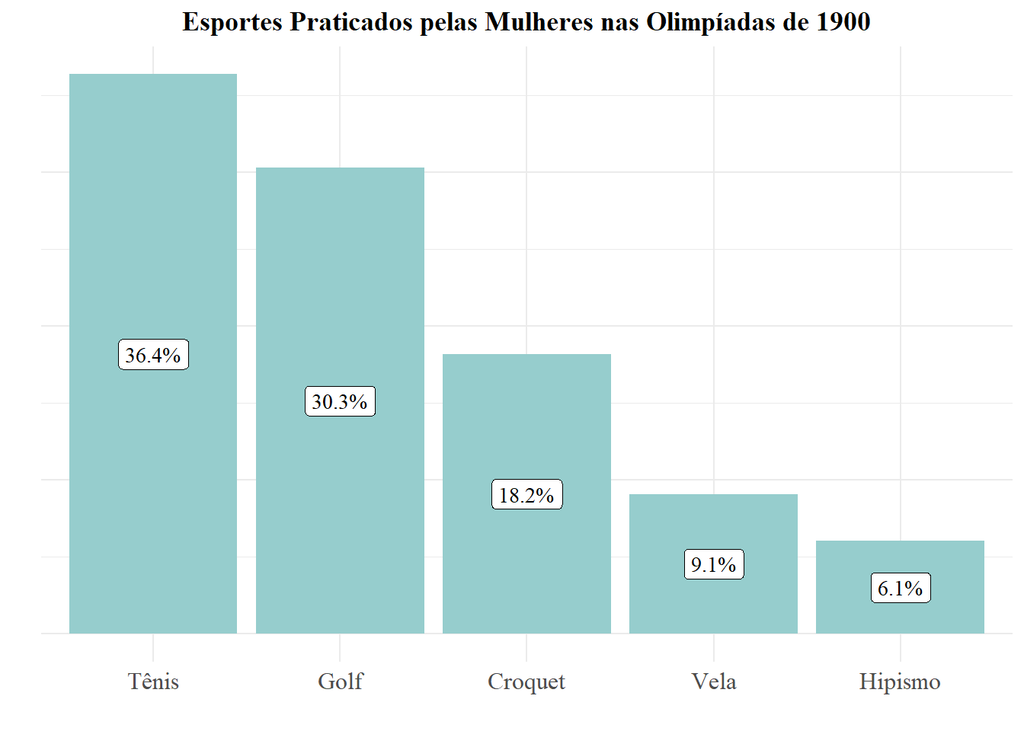

**4. Considerações Finais**

Nesta análise de dados foi possível observar por meios dos gráficos e tabela apesentados a desigualdade entre homens e mulheres na participação nas Olimpíadas ao longo do século XX e XXI assim como o seu avanço, com expressivo crescimento, da prticipação feminina ao longo do tempo. É importante lembrar que as mulheres foram proibidas de participar do primeiro evento por razões sexistas e hoje competem demonstrando habilidade e capacidade iguais aos competidores masculinos, como podemos observar no gráficos das medalhas: conforme aumento da participação feminina também é possível observar aumento proporcional na quantidade de medalhas por elas conquistadas.